# Module 3 Exam

## Introduction

The price of an option can be calculated as the expectation under risk neutral density $Q$ of the payoff at expiry discounted at the risk free rate. It is represented as follows:

$$ V(S,t) = e^{-r (T-t)}E^Q[Payoff(S)]$$

Here the risk free rate is assumed to be constant. The expectation can be found numerically using a Monte Carlo simulation.

The steps in a typical Monte Carlo simulation procedure to price options is as follows:

1. Simulate the risk neutral process of the underlying asset price with the initial value being the current value of the underlying till expiry.
2. Calculate the payoff of the option for the simulated path.
3. Repeat the above to obtain multiple simulations.
4. Take the expected value of the payoffs and discount it to current time using the risk free date.

If the underlying is the stock price, the risk neutral process is a geometric brownian motion given by the SDE:

$$dS = r S dt+\sigma S dX$$

where $\sigma$ is the standard deviation of returns, $r$ is the risk free rate and $dX$ is normally distributed with mean zero and variance $dt$.

To simulate the underlying the SDE must be discretized to a number of time steps. There are different methods to discretize the SDE. Based on the choice of the discretization scheme, the accuracy will vary. The objective of the paper is to implement the valuation of asian, binary and lookback options by using different discretization methods to simulate the underlying asset price. The different methods used are:

1. Closed Form Solution
2. Euler Maruyama Scheme
3. Millstein Scheme

The next sections explain the discretization schemes and provide an overview of the exotic options implemented.

## Discretization Schemes

### Closed Form Solution

The closed form solution is derived from solving the SDE as follows:

$$ dS = r Sdt +\sigma Sdx$$

By Ito's Lemma, the SDE of F(S) can be derived as:

$$dF = \frac{\partial{F}}{\partial{S}}dS + \frac{1}{2}\frac{\partial^2 F}{\partial S^2} (dS)^2$$

By substituting F(S) = log(S) we get the following SDE:

$$d(logS) = (r-\frac{1}{2}\sigma^{2}) dt +\sigma dX$$

By solving the SDE we get,

$$S_T = S_t e^{(r-\frac{1}{2}\sigma^2)(T-t)+\sigma (X_T-X_t)}$$

If the option is European or not path dependent, the terminal stock price can be calculated using the above equation. For path dependent exotic options, the above equation needs to be discretized. The stock price at time $t+\Delta t$ can be calculated from time $t$ as:

$$ S_{t+\Delta t} = S_t e^{(r-\frac{\sigma^2}{2})\Delta t+\sigma (X_{t+\Delta t}-X_{t})}$$

which can be written as
$$ S_{t+\Delta t} = S_t e^{(r-\frac{\sigma^2}{2})\Delta t + \sigma \phi \sqrt{\Delta t}}$$

where $\phi$ is a standard normal random variable.

### Euler Maruyama Scheme

The Euler Maruyama Scheme is obtained by discretizing the SDE for the asset price as shown below:

$$ \Delta S_t = r S_t \Delta t+ \sigma S_t \phi \sqrt{\Delta t}$$

which implies,

$$S_{t+\Delta t} = S_t (1+r \Delta t+ \sigma \phi \sqrt{\Delta t})$$

Comparing it with the closed form solution, the Euler Maruyama scheme has an error of $O(\Delta t)$. This can be seen by expanding the closed form solution using Taylor Series expansion.

$$\begin{align} S_{t+\Delta t} &= S_t e^{(r-\frac{1}{2}\sigma^2)\Delta t + \sigma \phi \sqrt{\Delta t}}\\ &\approx S_t (1+r \Delta t+ \sigma \phi \sqrt{\Delta t}) + O(\Delta t) \end{align} $$

### Milstein Scheme

The milstein scheme improves the accuracy of the Euler Discretization scheme by including higher order terms as shown below.

$$\begin{align} S_{t+\Delta t} &= S_t e^{(r-\frac{1}{2}\sigma^2)\Delta t + \sigma \phi \sqrt{\Delta t}}\\ &\approx S_t(1+(r-\frac{\sigma^2}{2})\Delta t +\sigma \phi \sqrt{\Delta t}+\frac{1}{2}\sigma^2 \phi^2 \Delta t) + O({\Delta t}^{3/2})\\ &\approx S_t(1+r\Delta t +\sigma \phi \sqrt{\Delta t}+\frac{1}{2}\sigma^2 (\phi^2-1) \Delta t) + O({\Delta t}^{3/2}) \end{align}$$

The error is of $O({\Delta t}^{\frac{3}{2}})$ which is more accurate than the Euler Maruyama scheme.

The order of the error for all the schemes is estimated in section 5.2

## Overview of the different call options

### Vanilla Option

The payoff of a vanilla call option is given below.

$$Payoff_{(vanilla \ call)} = max(S-E,0)$$

### Asian Option

The main feature of the Asian option is that the payoff of the option at expiry is based on the average price calculated over the time period. The Asian option can be classified into fixed strike or floating strike. The payoff functions for both types of call options are given below.

$$\begin{align} {Payoff}_{(fixed \ strike \ call)} &= max(avg(S)-E,0)\\ {Payoff}_{(floating \ strike \ call)} &= max(S_T-avg(S),0)\\ \end{align} $$

The average calculated can be discretely sampled or continuously sampled. It can be arithmetic or geometric. In this paper, the average calculated is arithmetic and the strike is fixed. If n is the number of time steps, the payoff used to value the Asian call option is:

$$Payoff = max(\frac{1}{n}\sum_{i=1}^{n} S^{(i)} - E,0)$$

In other words, the average is calculated at n equally spaced points in time.

### Binary Option

The binary call option has a payoff of 1 if the asset price is above the strike at expiry. Its payoff is defined using the heaviside function as shown below:

$$ Payoff_{(binary \ call)} = \mathcal{H}(S-E) = \textbf{1}_{\{S>E\}}$$

### Lookback Option

The payoff of a lookback option is defined based on the maximum or minimum of the asset price over the time period. It can also classified into fixed or floating strike. The payoff of the fixed strike lookback option is given below:

$$Payoff_{(fixed \ strike \ Call)} = max(S_{max}-E,0)$$

The payoff of floating strike lookback call is given below:

$$Payoff_{(floating \ strike \ Call)} = max(S-S_{min},0)$$

In this paper, the implementation is done for the fixed strike option.

## Monte Carlo Simulation

```python
import numpy as np
import pandas as pd
import matplotlib.pyplot as plt
import math
import matplotlib
import warnings
import cufflinks as cf
from scipy import stats as st
from mpl_toolkits import mplot3d
```

```python
warnings.filterwarnings("ignore")
plt.style.use("seaborn")
cf.set_config_file(offline=True)
pd.set_option("display.max_rows",None)
```

### Implementation

```python
class MonteCarlo():

    def __init__(self, S0, E, r, sig, T, nts, n_sim):
        self.S0 = S0                 # Current stock price
        self.E = E                   # Strike Price
        self.r = r                   # Risk free rate
        self.sig = sig               # Volatility
        self.T = T                   # Time to expiry (T-t)
        self.nts = nts               # No. of time steps
        self.n_sim = n_sim           # No. of simulations
        self.dt = T/nts
        self.phi = self.normal_generator()

    def normal_generator(self):
        return np.random.randn(self.nts, self.n_sim)

    def closed_form_scheme(self):
        values = np.zeros((self.nts+1, self.n_sim))
        values[0, :] = self.S0
        for i in range(1, self.nts+1):
            values[i, :] = values[i-1, :]*np.exp((self.r-0.5*self.sig**2)*self.dt
                                                 +self.sig*self.phi[i-1, :]*(self.dt**0.5))
        return values

    def Euler_Maruyama_scheme(self):
        values = np.zeros((self.nts+1, self.n_sim))
        values[0, :] = self.S0
        for i in range(1, self.nts+1):
            values[i, :] = values[i-1, :]*(1+self.r*self.dt+self.sig*self.phi[i-1, :]*(self.dt**0.5))
        return values

    def Milstein_scheme(self):
        values = np.zeros((self.nts+1, self.n_sim))
        values[0, :] = self.S0
        for i in range(1, self.nts+1):
            values[i, :] = values[i-1, :]*(1+self.r*self.dt+self.sig*self.phi[i-1, :]*(self.dt**0.5)
                                           + 0.5*self.sig**2*(self.phi[i-1]**2-1)*self.dt)
        return values

    def payoff_vanilla(self,s):
        return np.maximum(s[-1,:]-self.E,0)

    def payoff_asian(self,s):
        return np.maximum(np.mean(s,axis=0)-self.E,0)

    def payoff_binary(self,s):
        return np.maximum(np.where(s[-1,:]>=self.E,1,0),0)

    def payoff_lookback(self,s):
        return np.maximum(np.max(s,axis=0)-self.E,0)

    def option_price(self,scheme,payoff):
        payoff_values = payoff(scheme())
        return np.mean(payoff_values)*np.exp(-self.r*self.T)
```

### Initializing Parameters

```python
S0 = 100     # Current Stock Price
E = 100      # Strike Price
r = 0.05     # Risk Free Rate
sig = 0.2    # Volatility
T = 1        # Time to Expiry
nts = 252    # Number of Time Steps
n_sim = 1000 # No. of Simulations
```

## Comparison of the different schemes

### Single simulation of a stock price

Using the class created above, the results of a single stock price simulation over 10 time steps is compared between different methods. The results is shown in the data frame below.

```python
m = MonteCarlo(S0,E,r,sig,T,10,1)
df = pd.DataFrame({"Time":[i*T/10 for i in range(11)],
                   "Standard Normal": np.hstack([np.nan,m.phi.flatten()]),
                  "Closed Form":m.closed_form_scheme().flatten(),
                  "Euler Maruyama":m.Euler_Maruyama_scheme().flatten(),
                  "Milstein":m.Milstein_scheme().flatten()})
df
```

|  | Time | Standard Normal | Closed Form | Euler Maruyama | Milstein |
| --- | --- | --- | --- | --- | --- |
| 0 | 0.0 | NaN | 100.000000 | 100.000000 | 100.000000 |
| 1 | 0.1 | 0.329719 | 102.414000 | 102.585323 | 102.407066 |
| 2 | 0.2 | -0.959435 | 96.673896 | 96.873373 | 96.688761 |
| 3 | 0.3 | -0.672498 | 92.926690 | 93.237471 | 92.953867 |
| 4 | 0.4 | -0.942084 | 87.814642 | 88.148323 | 87.859288 |
| 5 | 0.5 | -1.555037 | 79.828381 | 79.919751 | 79.906891 |
| 6 | 0.6 | 0.409906 | 82.171113 | 82.391247 | 82.245028 |
| 7 | 0.7 | -0.163264 | 81.571348 | 81.952453 | 81.646907 |
| 8 | 0.8 | -0.260750 | 80.478237 | 81.010714 | 80.556488 |
| 9 | 0.9 | 0.264430 | 82.081352 | 82.770595 | 82.156654 |
| 10 | 1.0 | -2.619573 | 69.758168 | 69.471319 | 69.919255 |

The above table shows the stock price values simulated using closed form, Euler Maruyama and the milstein schemes. The stock prices are simulated for 10 time steps over a period of 1 year. Looking at the values, it is evident that the Milstein scheme produces values which are closer to the closed form solution than Euler-Maruyama scheme. The average deviation from closed form solution for both schemes is given below.

```python
print("Absolute Average Deviation from Closed Form Solution")
print("------------------------------------------------")
print("Euler Mauyama :",np.round(np.mean(np.abs(df["Closed Form"]-df["Euler Maruyama"])),4))
print("Milstein :",np.round(np.mean(np.abs(df["Closed Form"]-df["Milstein"])),4))
```

```
Absolute Average Deviation from Closed Form Solution
------------------------------------------------
Euler Mauyama : 0.2924
Milstein : 0.0578
```

The stock price approximations provided by Milstein scheme is more accurate than the Euler Maruyama scheme as expected.

### Estimation of error as function of time step

Here the error from the closed form solution is estimated as a function of time for both schemes. In section 2, the order of the error which was mathematically provided is proved here numerically.

The average deviation from the closed form solution is estimated for different time steps. The time steps are decreased on an exponential scale as implemented below.

```python
time_step_arr = 1/np.array([10**i for i in range(7)])
error_em = []
error_mil = []
for i in time_step_arr:
    m = MonteCarlo(S0,E,r,sig,i,1,100)
    error_em.append(np.mean(np.abs(m.closed_form_scheme()[-1]-m.Euler_Maruyama_scheme()[-1])))
    error_mil.append(np.mean(np.abs(m.closed_form_scheme()[-1]-m.Milstein_scheme()[-1])))
```

The results are plotted below:

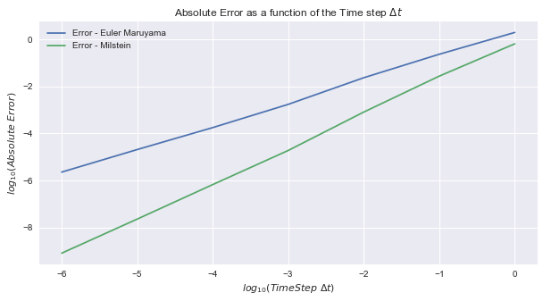

```python
plt.figure(figsize=(10,5))
plt.plot(np.vectorize(math.log)(time_step_arr,10),np.vectorize(math.log)(error_em,10),label="Error - Euler Maruyama")
plt.plot(np.vectorize(math.log)(time_step_arr,10),np.vectorize(math.log)(error_mil,10),label="Error - Milstein")
plt.xlabel("$log_{10}(Time Step\ \Delta t)$")
plt.ylabel("$log_{10}(Absolute \ Error)$")
plt.title("Absolute Error as a function of the Time step $\Delta t$")
plt.legend()
plt.show()
```

The plot shows $log(\Delta t)$ plotted against $log(Error)$. There are two observations here. First is that the error from Milstein scheme is always lesser than Euler Maruyama as expected. The second observation is that the error decreases as $\Delta t \to 0$ and the slope of the Euler Maruyama line is ~1 and the slope of the milstein is ~1.5. This indicates that the error of Euler Maruyama scheme is of $O(\Delta t)$ and for Milstein scheme, the error is of $O(\Delta t^{3/2}$)

## Pricing Exotic Options

Here various call options are priced using the same Montecarlo class and the parameters initialized in section 4.2.

```python
m = MonteCarlo(S0,E,r,sig,T,nts,n_sim)
```

### Asian Option

The Asian option prices for each of the different schemes is given below:

```python
print("Closed Form:", np.round(m.option_price(m.closed_form_scheme,m.payoff_asian),4))
print("Euler Maruyama:", np.round(m.option_price(m.Euler_Maruyama_scheme,m.payoff_asian),4))
print("Milstein:", np.round(m.option_price(m.Milstein_scheme,m.payoff_asian),4))
```

```
Closed Form: 5.9852
Euler Maruyama: 5.9859
Milstein: 5.9841
```

The option prices are almost same indicating not much error maybe due to the averaging function in the payoff of the Asian.

### Binary Option

The binary option values for each of the different schemes is given below:

```python
print("Closed Form:", np.round(m.option_price(m.closed_form_scheme,m.payoff_binary),4))
print("Euler Maruyama:", np.round(m.option_price(m.Euler_Maruyama_scheme,m.payoff_binary),4))
print("Milstein:", np.round(m.option_price(m.Milstein_scheme,m.payoff_binary),4))
```

```
Closed Form: 0.5374
Euler Maruyama: 0.5374
Milstein: 0.5374
```

### Lookback Option

The lookback option values for each of the different schemes is given below:

```python
print("Closed Form:", np.round(m.option_price(m.closed_form_scheme,m.payoff_lookback),4))
print("Euler Maruyama:", np.round(m.option_price(m.Euler_Maruyama_scheme,m.payoff_lookback),4))
print("Milstein:", np.round(m.option_price(m.Milstein_scheme,m.payoff_lookback),4))
```

```
Closed Form: 18.7291
Euler Maruyama: 18.7256
Milstein: 18.7254
```

Again, there is not much difference in the option prices. One observation is that the lookback option prices are higher than the asian option prices. This is expected since the payoff of the lookback is based on maximum of the asset price path compared to average.

## Varying the Stock Price S

Here the current stock price is varied and the resulting option prices are plotted as a function of the stock price. First, functions for calculating and plotting the option prices are created. The results for each type of option are provided.

```python
def opt_price_by_S(scheme,payoff):
    s_values = [i*10 for i in range(26)]
    m_arr = [MonteCarlo(s,E,r,sig,T,nts,n_sim) for s in s_values]
    opt_prices = [m.option_price(eval("m."+scheme),eval("m."+payoff)) for m in m_arr]
    return pd.DataFrame({"Stock Price":s_values,"Option Price":opt_prices})
```

```python
def plot_prices_by_scheme(opt_price_func,payoff,title=""):
    plt.figure(figsize=(10,5))
    ax = plt.gca()
    opt_price_func("closed_form_scheme",payoff).plot(x=0,y=1,label = "Closed Form",ax=ax)
    opt_price_func("Euler_Maruyama_scheme",payoff).plot(x=0,y=1,label = "Euler Maruyama",ax=ax)
    opt_price_func("Milstein_scheme",payoff).plot(x=0,y=1,label = "Milstein",ax=ax)
    plt.legend()
    plt.ylabel("Option Price")
    plt.title(title)
    plt.show()
```

### Asian Option

The below plot shows the asian call option prices as a function of stock price. There seems to be no significant differences between the option prices.

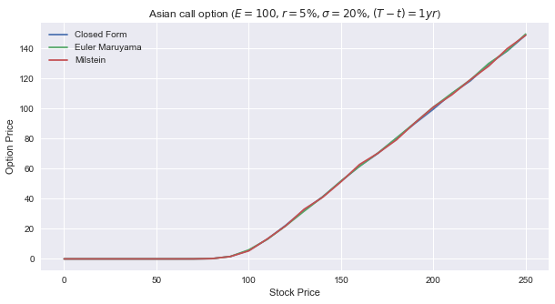

```python
plot_title = "Asian call option ($E=100,r=5\%,\sigma = 20\%, (T-t) = 1 yr$)"
plot_prices_by_scheme(opt_price_by_S,"payoff_asian",title=plot_title)
```

### Binary Option

The below plot shows the binary call option prices as a function of stock price. There seems to be no significant differences between the option prices. The pattern resembles the cdf of normal distribution which is expected since under the black scholes framework the value of the binary call option is $V = e^{-r \ (T-t)} \ N(d_2)$ and $d_2$ is just shifted $\log S$ when other parameters are constant.

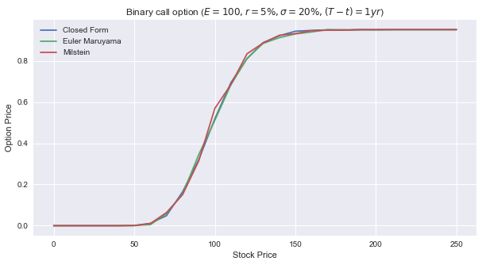

```python
plot_title = "Binary call option ($E=100,r=5\%,\sigma = 20\%, (T-t) = 1 yr$)"
plot_prices_by_scheme(opt_price_by_S,"payoff_binary",title=plot_title)
```

### Lookback Option

The below plot shows the lookback call option prices as a function of stock price. One observation is that the curvature of the lookback option is higher than the asian option.

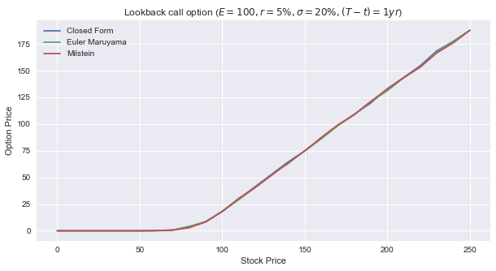

```python
plot_title = "Lookback call option ($E=100,r=5\%,\sigma = 20\%, (T-t) = 1 yr$)"
plot_prices_by_scheme(opt_price_by_S,"payoff_lookback",title=plot_title)
```

## Varying the time t

Here the time ($t$) price is varied from 0 to T and the resulting option prices are plotted as a function of $t$. The results for each type of option are provided.

```python
def opt_price_by_t(scheme,payoff):
    t_values = np.linspace(0,1,51)
    m_arr = [MonteCarlo(S0,E,r,sig,T-t,int((T-t)*252),n_sim) for t in t_values] # nts is changed so that dt is constant
    opt_prices = [m.option_price(eval("m."+scheme),eval("m."+payoff)) for m in m_arr]
    return pd.DataFrame({"Time":t_values,"Option Price":opt_prices})
```

### Asian Option

The below plot shows the asian call option prices as a function of time. As $t \to T$, the call option price decreases to the option payoff. The differences in value for the three schemes is not significant and can be reduced by increasing the number of simulations or increasing the time step.

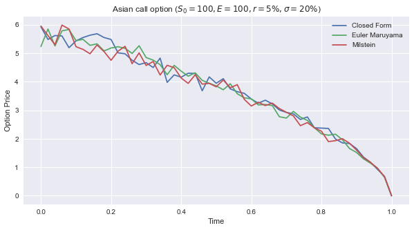

```python
plot_title = "Asian call option ($S_0 =100, E=100,r=5\%,\sigma = 20\%$)"
plot_prices_by_scheme(opt_price_by_t,"payoff_asian",title=plot_title)
```

### Binary Option

#### $S_0 = E$

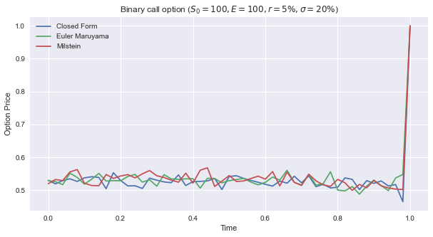

```python
plot_title = "Binary call option ($S_0 =100, E=100,r=5\%,\sigma = 20\%$)"
plot_prices_by_scheme(opt_price_by_t,"payoff_binary",title=plot_title)
```

It can be seen that as $t \to T$ the option price goes to the 1 if $S_0 >= E$ and 0 if $S_0 < E$. When $S_0 = E$, the option at time $t<T$ is almost constant.

#### $S_0 > E$

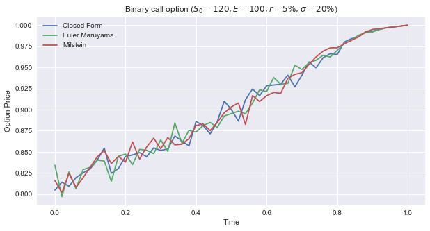

```python
S0 = 120
plot_title = "Binary call option ($S_0 =120, E=100,r=5\%,\sigma = 20\%$)"
plot_prices_by_scheme(opt_price_by_t,"payoff_binary",title=plot_title)
```

If $S_0 >E$, then binary call option price increases in value to 1 as $t \to T$.

#### $S_0 < E$

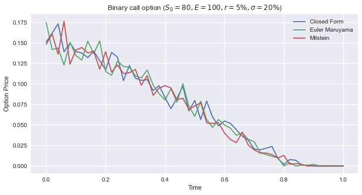

```python
S0 = 80
plot_title = "Binary call option ($S_0 =80, E=100,r=5\%,\sigma = 20\%$)"
plot_prices_by_scheme(opt_price_by_t,"payoff_binary",title=plot_title)
```

### Lookback Option

The below plot shows the lookback call option prices as a function of time.

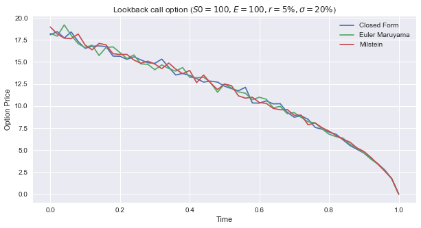

```python
S0 = 100 # Setting S0 back to 100
plot_title = "Lookback call option ($S0=100, E=100,r=5\%,\sigma = 20\%$)"
plot_prices_by_scheme(opt_price_by_t,"payoff_lookback",title=plot_title)
```

The pattern for lookback is similar to asian option and vanilla option. The call option decreases as $t \to T$.

## Varying the volatility of the stock

```python
def opt_price_by_vol(scheme,payoff):
    sig_values = np.linspace(0.05,1,26)
    m_arr = [MonteCarlo(S0,E,r,sig,T,nts,n_sim) for sig in sig_values]
    opt_prices = [m.option_price(eval("m."+scheme),eval("m."+payoff)) for m in m_arr]
    return pd.DataFrame({"Volatility":sig_values,"Option Price":opt_prices})
```

### Asian Option

The below plot shows the asian call option prices as a function of volatility. The option price increases linearly with increase in volatility.

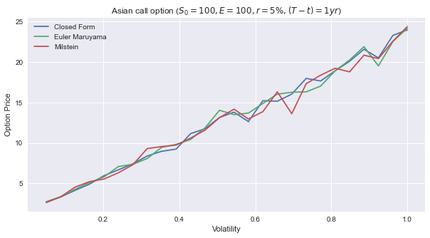

```python
plot_title = "Asian call option ($S_0 = 100, E=100,r=5\%, (T-t) = 1 yr$)"
plot_prices_by_scheme(opt_price_by_vol,"payoff_asian",title=plot_title)
```

### Binary Option

The below plot shows the binary call option prices as a function of volatility. The plots show different patterns for different values of the current stock price. This is because the slope (Vega) depends on the stock price and exercise price. This can be mathematically derived as shown below:

Under the black scholes framework the binary call option price is:

$$\begin {align} V &= e^{-r \ (T-t)} \ N(d_2)\\ \frac{\partial V}{\partial \sigma} &= e^{-r \ (T-t)} \ N^{'}(d_2) \ \frac{\partial {d_2}}{\partial \sigma}\\\\ d_2 &= \frac{\ln(S_t/E)+(r-\dfrac{1}{2}\sigma^2)(T-t)}{\sigma \sqrt{T-t}}\\ \frac{\partial {d_2}}{\partial \sigma} &= -\frac{(\ln(S_t/E)+r(T-t))}{\sigma^2 \sqrt{T-t}}-\frac{1}{2}(\sqrt{T-t}) \end{align} $$

For $\dfrac{\partial{V}}{\partial \sigma}$ to be positive, the condition to be satisfied is $E > S_t e^{(r+\frac{1}{2}\sigma^2)(T-t)}$

#### $S_0 = E$

Here $S_0 = E$ meaning the condition is not satisfied for any value of $\sigma$.

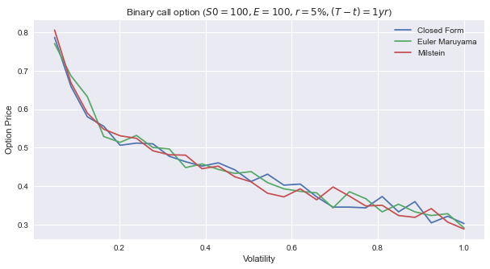

```python
plot_title = "Binary call option ($S0=100, E=100,r=5\%, (T-t) = 1 yr$)"
plot_prices_by_scheme(opt_price_by_vol,"payoff_binary",title=plot_title)
```

#### $S_0 > E$

Here $S_0>E$ and once again the slope is negative for all $\sigma$.

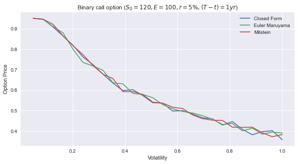

```python
S0=120
plot_title = "Binary call option ($S_0=120, E=100,r=5\%, (T-t) = 1 yr$)"
plot_prices_by_scheme(opt_price_by_vol,"payoff_binary",title=plot_title)
```

#### $S_0 < E$

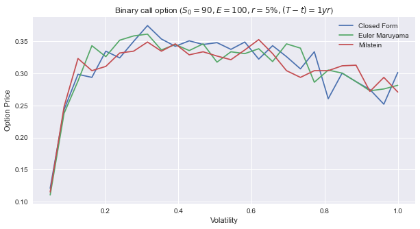

```python
S0=90
plot_title = "Binary call option ($S_0=90, E=100,r=5\%, (T-t) = 1 yr$)"
plot_prices_by_scheme(opt_price_by_vol,"payoff_binary",title=plot_title)
```

### Lookback Option

The below plot shows the lookback call option price as a function of volatility. The option value increases linearly with volatility.

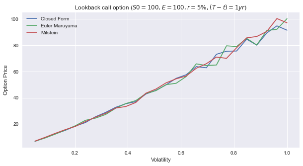

```python
S0= 100 # Reset to 100
plot_title = "Lookback call option ($S0 =100, E=100,r=5\%, (T-t) = 1 yr$)"
plot_prices_by_scheme(opt_price_by_vol,"payoff_lookback",title=plot_title)
```

## Varying the risk free rate

Here the risk free is varied and the resulting option prices are plotted as a function of the risk free rate.

```python
def opt_price_by_r(scheme,payoff):
    r_values = np.linspace(0.01,1,25)
    m_arr = [MonteCarlo(S0,E,r,sig,T,nts,n_sim) for r in r_values]
    opt_prices = [m.option_price(eval("m."+scheme),eval("m."+payoff)) for m in m_arr]
    return pd.DataFrame({"Risk Free Rate":r_values,"Option Price":opt_prices})
```

### Asian Option

The below plot shows the asian call option prices as a function of the risk free rate. The option price increases linearly with the risk free rate.

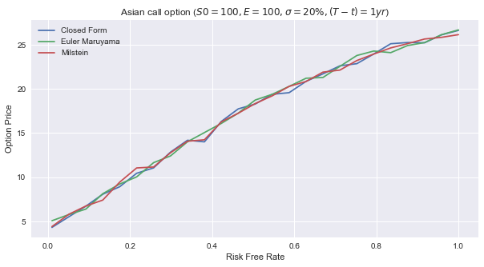

```python
S0=100
plot_title = "Asian call option ($S0 = 100,E=100,\sigma = 20\%, (T-t) = 1 yr$)"
plot_prices_by_scheme(opt_price_by_r,"payoff_asian",title=plot_title)
```

### Binary Option

The below plot shows the binary call option prices as a function of the risk free rate. The option increases up to certain levels of the risk free rate and then decreases.

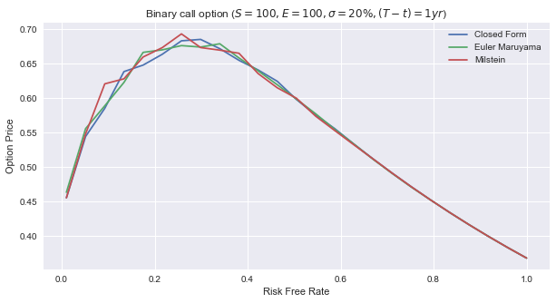

```python
plot_title = "Binary call option ($S=100, E=100,\sigma = 20\%, (T-t) = 1 yr$)"
plot_prices_by_scheme(opt_price_by_r,"payoff_binary",title=plot_title)
```

### Lookback Option

The below plot shows the lookback call option prices as a function of the risk free rate. The pattern is similar to the asian option.

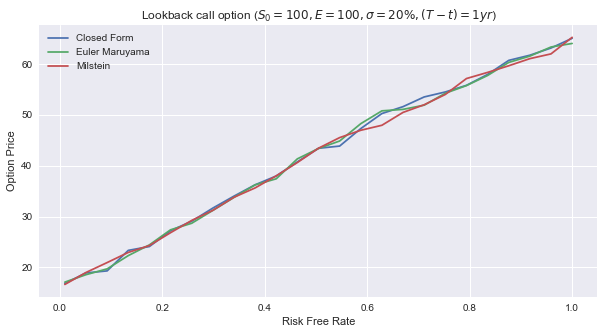

```python
S0=100
plot_title = "Lookback call option ($S_0=100, E=100,\sigma = 20\%, (T-t) = 1 yr$)"
plot_prices_by_scheme(opt_price_by_r,"payoff_lookback",title=plot_title)
```

## Testing the convergence of the MonteCarlo Simulation Estimates

In this section, the convergence of the option price obtained by using montecarlo simulation. To test the convergence, the analytical solution of the option price must be known. Here the convergence is tested for vanilla call options and binary call options since the explicit solution can be easily derived from the black scholes PDE for these options.

The functions for testing the convergence and plotting the results are created here. The simulation is done using only the closed form scheme.

```python
def opt_price_convergence(scheme,payoff):
    n_values = [1000*i for i in range(1,21)]
    m_arr = [MonteCarlo(S0,E,r,sig,T,nts,n) for n in n_values]
    opt_prices = [m.option_price(eval("m."+scheme),eval("m."+payoff)) for m in m_arr]
    return pd.DataFrame({"Number of simulations":n_values,"Option Price":opt_prices})
```

```python
def plot_prices_by_scheme_convergence(payoff,BS_price,title=""):
    plt.figure(figsize=(10,5))
    ax = plt.gca()
    opt_price_convergence("closed_form_scheme",payoff).plot(x=0,y=1,label = "Closed Form",ax=ax)
    plt.axhline(y=BS_price,xmin=0,xmax=1,label="Black Scholes Price",ls="--",c="r")
    plt.legend()
    plt.ylabel("Option Price")
    plt.title(title)
    plt.show()
```

### Vanilla Option

The black scholes formula for a vanilla call option at $t=0$ is given by:

$$ V = S_0 N(d_1) - E e^{-r(T-t)} N(d_2)$$

where $d_1 = \frac{\ln({S_0}/{E})+(r+\frac{1}{2}\sigma^2)(T)}{\sigma \sqrt{T}}$ and $d_2 = d_1-\sigma \sqrt{T}$

```python
def BS_vanilla(S0,E,r,sig,T):
    d1 = (np.log(S0/E)+(r+0.5*sig**2)*T)/(sig*T**0.5)
    d2 = d1 - sig*T**0.5
    return S0*st.norm.cdf(d1)-E*np.exp(-r*T)*st.norm.cdf(d2)
```

```python
BS_vanilla_price = BS_vanilla(S0,E,r,sig,T)
np.round(BS_vanilla_price,4)
```

```
10.4506
```

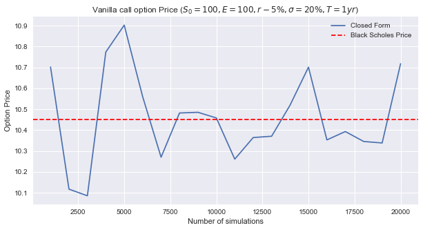

```python
plot_title = "Vanilla call option Price ($S_0 = 100, E=100,r-5\%,\sigma=20\%,T=1yr$)"
plot_prices_by_scheme_convergence("payoff_vanilla",BS_vanilla_price,title=plot_title)
```

The montecarlo estimate oscillates around the true value of the option. As $n \to \infty$ the value converges to the black scholes price.

### Binary Option

The black scholes formula for a binary call option at $t=0$ is given by:

$$ V = e^{-r(T-t)} N(d_2)$$

where $$d_2 = \frac{\ln({S_0}/{E})+(r-\frac{1}{2}\sigma^2)(T)}{\sigma \sqrt{T}}$$

```python
def BS_binary(S0,E,r,sig,T):
    d2 = (np.log(S0/E)+(r-0.5*sig**2)*T)/(sig*T**0.5)
    return np.exp(-r*T)*st.norm.cdf(d2)
```

```python
BS_binary_price = BS_binary(S0,E,r,sig,T)
np.round(BS_binary_price,4)
```

```
0.5323
```

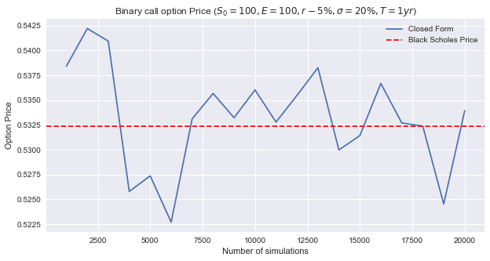

```python
plot_title = "Binary call option Price ($S_0 = 100, E=100,r-5\%,\sigma=20\%,T=1yr$)"
plot_prices_by_scheme_convergence("payoff_binary",BS_binary_price,title=plot_title)
```

## Conclusion

In this report, the following points were explored.

1. Pricing exotic and path dependent options using Montecarlo simulations
2. Simualting the stock price using different discretization schemes and checking the accuracy. Euler Mauryama scheme produced estimates with an error of $O(\Delta t)$ where as Milstein scheme produced estimates with error of $O({\Delta t}^{3/2})$
3. Varying the different parameters $S_0, t, \sigma, r$ and checking the effect of each parameter on the option price.
4. Testing the convergence of the Montecarlo simulation results to the black scholes formulae.